# Informative Range

David Smith

`~/Analytics/Informative-Range.Rmd`

RAMP Library $\uparrow$ Nav Hub | Analytics, Adaptive Malaria Control

## -

For any relationship between two variables $x$ and $y$ where
$$y =
f(x) + \epsilon,$$
we want to define the **informative range** for $y \in (y_l, y_u)$ and the **informative domain** for $x \in (x_l, x_u)$ where values of $x$ can be used to predict $y$ with defined degree of accuracy.

If $\epsilon=0$, then $f'(x)$ indicates the relative amount of information about $y$ around $x$.

## linear

If the relationship between two variables is linear, then information about one variable is equally informative about another across its entire range. For example, if we have the fitted relationship for a set of points

$$y = f(x) + \epsilon = mx + b +
\epsilon$$

then $f'(x)=m,$ So the relative amount of information about $y$ is constant across the entire range of $x.$ We can thus $x$ to predict $y$ and *vice versa.*

In the following, if we accept that the fitted relationship is the *true* relationship (a reasonable but risky assumption; in this case, the *true* value was $m=2$), we know that a one unit change in $x$ will result in an expected 7/4 unit change in $y$. We can, moreover, use $y$ to predict $x$:

$$x \approx \frac{y-b +
\epsilon}{m}$$

so a one unit change in $y$ will result in an expected $4/7$ change in $x$. Notably, the error scales with $1/m$.

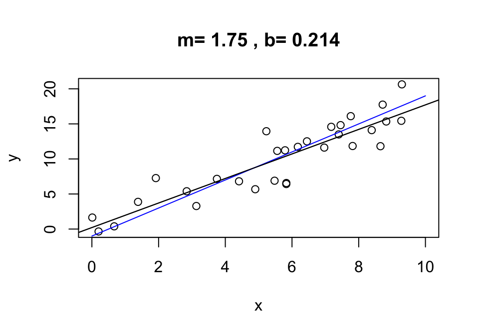

## sigmoidal

If the relationship between two variables is sigmoidal, then the amount of information about the variable $y$ depends on the value of $x$:

```r
ll = 5.889
```

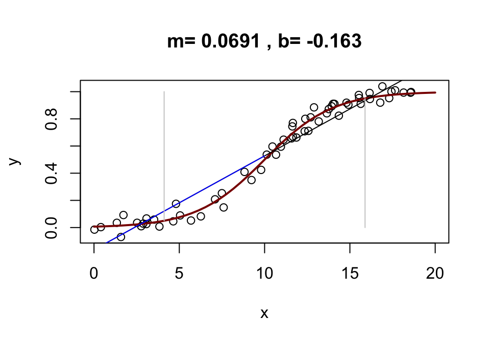

We note that the greatest change in $y$ is found when $x$ is around $d=10$. Since the range of $y \in c(0,1)$, about 90% of the total variance in y occurs for $x\in c(4.11, 15.889).$

```r
c(sigmoidF(10+ll, .5, 10), sigmoidF(10-ll, .5, 10))
```

```
## [1] 0.9500029 0.0499971
```

In this case, we can write down a closed form expression for the change in $y$ by looking at the derivative of the sigmoidal function:

$$\frac{S
e^{-S(x-d)}}{(1-e^{-S(x-d)})^2}$$

Around $x=10$, a one-unit change in $x$ will result in a maximum 12% change in $y$, but as we move away from the peak, the amount of information about $y$ from $x$ declines.

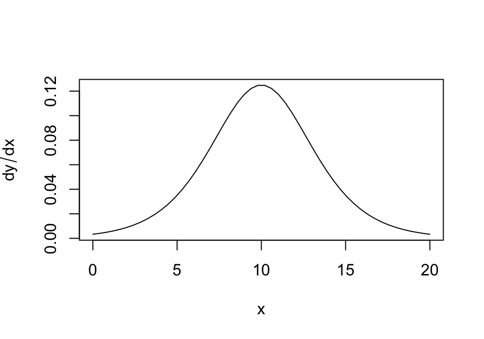

The right way to do prediction is probably to try and fit a sigmoidal curve to the data, but We note that the fitted line provides a poor fit by visual inspection. Since the residual error should be uniformly distributed with no pattern, we can also see how bad we’ve done by plotting the residuals:

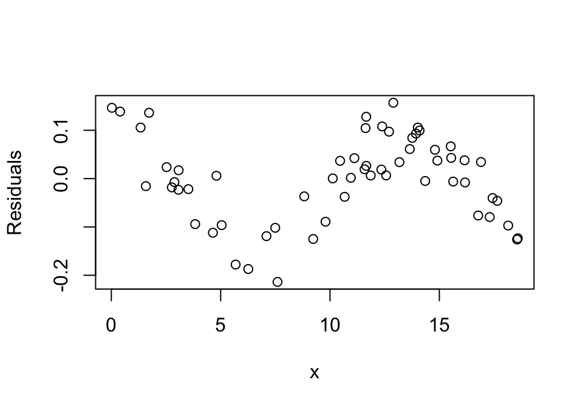

If, however, we include data to values of $x$ that contain 90% of the range of $y$, we get a reasonably good linear fit, to the true relationship. The 9% slope from the fitted line is about 3/4 of the maximum 12% slope predicted above.

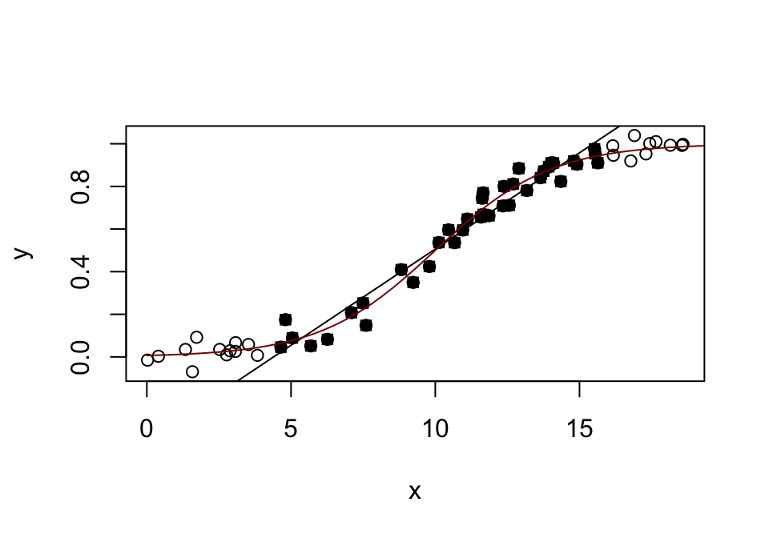

```
##
## Call:
## lm(formula = ysub ~ xsub)
##
## Residuals:
##       Min        1Q    Median        3Q       Max
## -0.141548 -0.034737  0.003852  0.033085  0.137366
##
## Coefficients:
##              Estimate Std. Error t value Pr(>|t|)
## (Intercept) -0.396674   0.037822  -10.49 1.71e-12 ***
## xsub         0.090297   0.003258   27.71  < 2e-16 ***
## ---
## Signif. codes:  0 '***' 0.001 '**' 0.01 '*' 0.05 '.' 0.1 ' ' 1
##
## Residual standard error: 0.0634 on 36 degrees of freedom
## Multiple R-squared:  0.9552, Adjusted R-squared:  0.954
## F-statistic: 768.1 on 1 and 36 DF,  p-value: < 2.2e-16
```

If we plot the residuals, it’s hard to tell the relationship within the subsetted data are not linear.

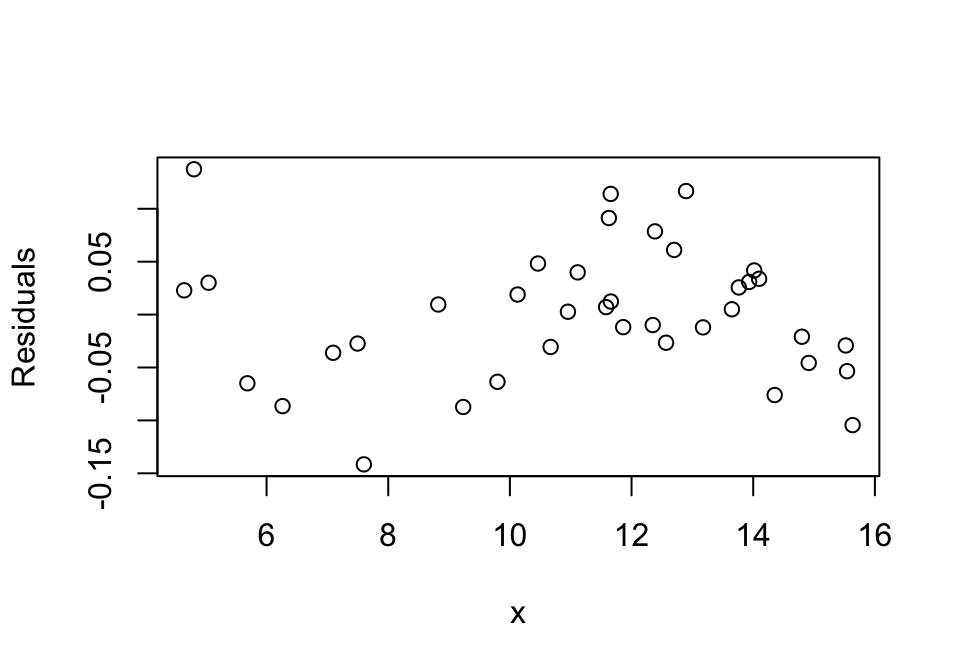